# Mini-project

```r
require(BSDA)
require(EnvStats)
library(BSDA)
library(EnvStats)
library(ggplot2)
library(hrbrthemes)
library(dplyr)
library(tidyr)
library(viridis)
library(corrplot)
```

## Generating data

### Basically, we did’t have any dataset because it is rather hard to find such data on the Internet, so we decided that we will scrap it from official site of [English Premier League] (https://www.premierleague.com/results?co=1&se=363&cl=-1). So, our dataset is a set of all matches in EPL of different seasons with full statistics of each match.

All the data used here was scrapped by ourselves and you can analize this proces by the following link on GitHub: (https://github.com/SevkavTV/Betting-Analysis)

#### Modelling shot sttempts inside and outside the pen area as well as possession against total goals scored in a single season.

For this step in our research, we create linear models of attempted shots inside and outside the box against goals scored in a single seasons and ball possession percentage by teams against their total score in a single season. For this part we track teams contending in 2020-2021 English Premier League season and track their statistics such as ball possession and attempted scores and their actual scores for seasons of 2016-2017, 2017-2018, 2018-2019, 2019-2020, 2020-2021 of English Premier League.

### Checking the corellation between the parameters.

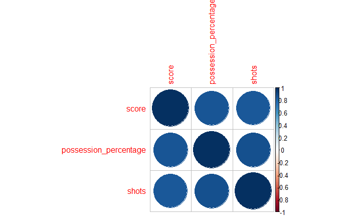

```r
scores.data <- read.csv('data/shots.csv')

cor <- cor(scores.data[, c("score", "possession_percentage", "shots")])
corrplot(cor, method = "circle")
```

since our values of goal attempts and ball possession are highly correlated, we ought not to use them simultaneously in a single linear regression model. Instead we will use them separately for multiple simple regression models.

### Normality of the data

in this step we check if the dependent data (in our case the total scores of a team in a single season for each of the seasons from 2016-17: 2020-21) follows the normal distribution so we can proceed with our linear regression.

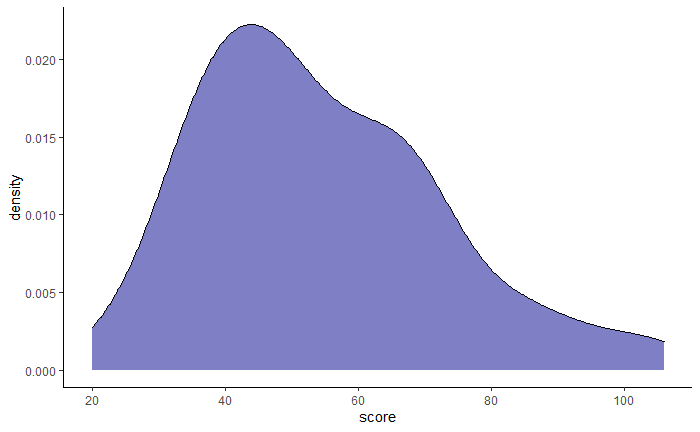

```r
ggplot(scores.data) + geom_density(aes(score), fill = "darkblue", alpha = 0.5) + theme_classic()
```

```r
shots.data.lm <- lm(score ~ shots, data = scores.data)
```

### Linearity of the data

for the next step we check the linearity of relations between shot attempts and goals.

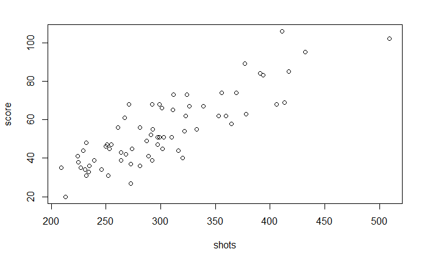

```r
plot(score ~ shots, data = scores.data)
```

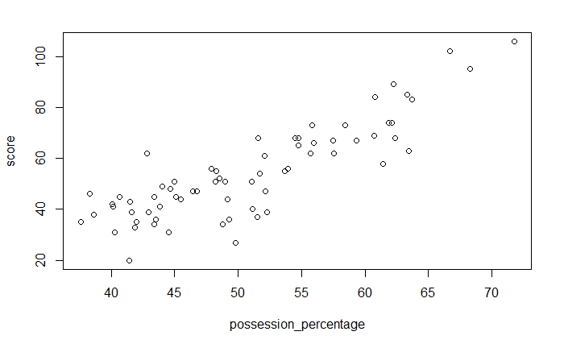

```r
plot(score ~ possession_percentage, data = scores.data)
```

the relationship between dependent and indendent data are linear.

### Linear regression analysis

```r
shots.data.lm <- lm(score ~ shots, data = scores.data)
summary(shots.data.lm)
```

```
Call:
lm(formula = score ~ shots, data = scores.data)

Residuals:
    Min      1Q  Median      3Q     Max
-20.172  -6.260  -1.073   6.258  24.006

Coefficients:
            Estimate Std. Error t value Pr(>|t|)
(Intercept) -21.7167     5.9721  -3.636 0.000543 ***
shots         0.2523     0.0194  13.010  < 2e-16 ***
---
Signif. codes:  0 ‘***’ 0.001 ‘**’ 0.01 ‘*’ 0.05 ‘.’ 0.1 ‘ ’ 1

Residual standard error: 9.76 on 66 degrees of freedom
Multiple R-squared:  0.7195,    Adjusted R-squared:  0.7152
F-statistic: 169.3 on 1 and 66 DF,  p-value: < 2.2e-16
```

```r
possessions.data.lm <- lm(score ~ possession_percentage, data = scores.data)
summary(possessions.data.lm)
```

```
Call:
lm(formula = score ~ possession_percentage, data = scores.data)

Residuals:
     Min       1Q   Median       3Q      Max
-25.4192  -4.5298   0.6206   6.6108  22.7454

Coefficients:
                      Estimate Std. Error t value Pr(>|t|)
(Intercept)           -41.3385     7.1943  -5.746 2.53e-07 ***
possession_percentage   1.8828     0.1396  13.488  < 2e-16 ***
---
Signif. codes:  0 ‘***’ 0.001 ‘**’ 0.01 ‘*’ 0.05 ‘.’ 0.1 ‘ ’ 1

Residual standard error: 9.508 on 66 degrees of freedom
Multiple R-squared:  0.7338,    Adjusted R-squared:  0.7297
F-statistic: 181.9 on 1 and 66 DF,  p-value: < 2.2e-16
```

### Results Visualization

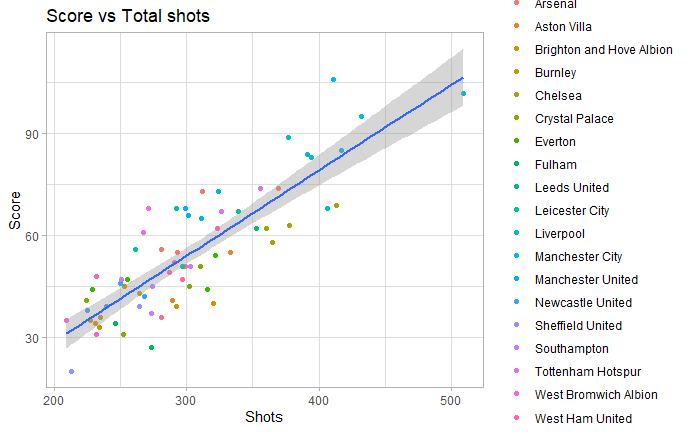

```r
ggplot(scores.data, aes(x=shots, y=score)) +
  geom_point(aes(col=team)) +
  geom_smooth(formula = y ~ x, method="lm") +
  labs(x= "Shots", y= "Score", title = "Score vs Total shots") +
  theme_light()
```

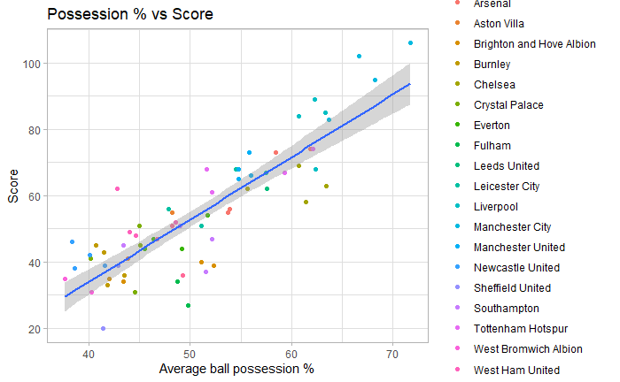

```r
ggplot(scores.data, aes(x=possession_percentage, y=score)) +
  geom_point(aes(col=team)) +
  geom_smooth(formula = y ~ x, method="lm") +
  labs(x= "Average ball possession %", y= "Score", title = "Possession % vs Score") +
  theme_light()
```

## Testing hypotheses.

### We have 2 hypotheses:

### 1. If two aggressive teams are playing and there was 1 or less goals in first half, there will be 2 or more goals in the second half.

### 2. If two defensive teams are playing and there was 3 or more goals in first half, there will be 1 or less goals in the second half.

### To test these hypotheses we have to determine which teams are agressive and which are defensive. We are modeling this based on mean statistics each has team for one season. We decided to take **final_third_entries, attempts_obox (shots outside from box), attempts_ibox (shots inside the box), total_offside** as statistics which will be responsible for attacking part and **total_tackle, blocked_pass, interception** as statistics which will be responsible for defensive part. In our opinion, these statistics can be very useful in determination which style of play has each team.

### For each of these statistics we calculated the mean for the whole season and mean for each team. Then, for each team we calculated the percentage difference of each statistics (corresponding plots you can find below).

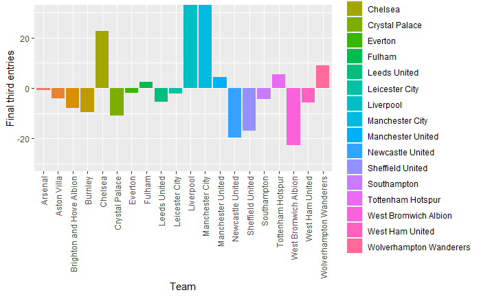

```r
means <- read.csv(file = 'data/means.csv');

ggplot(means,aes(team,final_third_entries_av_diff,fill=team))+
  geom_bar(stat="identity")+
  labs(x= "Team", y= "Final third entries") +
  theme(axis.text.x = element_text(angle = 90, vjust = 0.5, hjust=1)) +
  coord_cartesian(ylim = c(-30, 30))
```

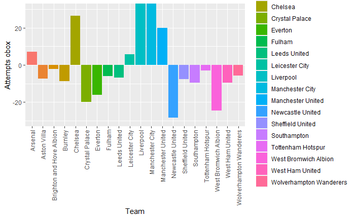

```r
ggplot(means,aes(team,attempts_obox_av_diff,fill=team))+
  geom_bar(stat="identity")+
  labs(x= "Team", y= "Attempts obox") +
  theme(axis.text.x = element_text(angle = 90, vjust = 0.5, hjust=1)) +
  coord_cartesian(ylim = c(-30, 30))
```

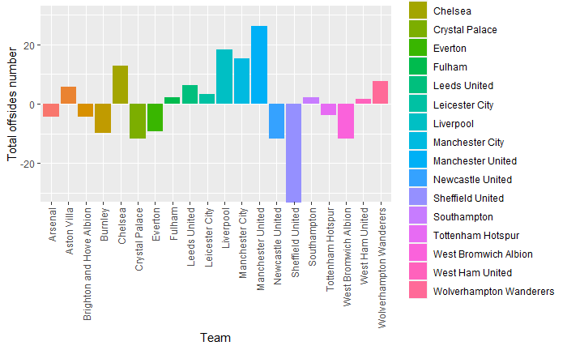

```r
ggplot(means,aes(team,total_offside_av_diff,fill=team))+
  geom_bar(stat="identity")+
  labs(x= "Team", y= "Total offsides number") +
  theme(axis.text.x = element_text(angle = 90, vjust = 0.5, hjust=1)) +
  coord_cartesian(ylim = c(-30, 30))
```

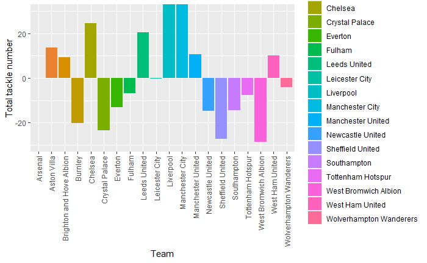

```r
ggplot(means,aes(team,total_tackle_av_diff,fill=team))+
  geom_bar(stat="identity")+
  labs(x= "Team", y= "Total tackle number") +
  theme(axis.text.x = element_text(angle = 90, vjust = 0.5, hjust=1)) +
  coord_cartesian(ylim = c(-30, 30))
```

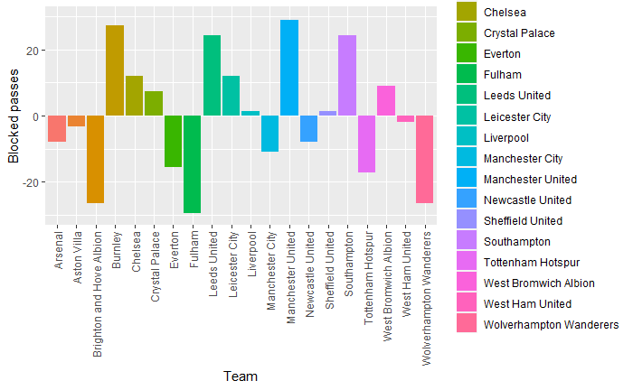

```r
ggplot(means,aes(team,blocked_pass_av_diff,fill=team))+
  geom_bar(stat="identity")+
  labs(x= "Team", y= "Blocked passes") +
  theme(axis.text.x = element_text(angle = 90, vjust = 0.5, hjust=1)) +
  coord_cartesian(ylim = c(-30, 30))
```

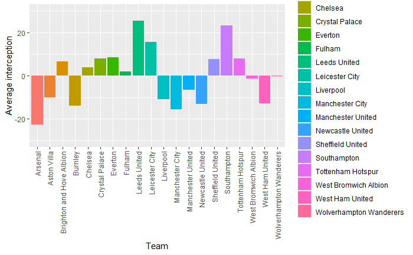

```r
ggplot(means,aes(team,interception_av_diff,fill=team))+
  geom_bar(stat="identity")+
  labs(x= "Team", y= "Average interception") +
  theme(axis.text.x = element_text(angle = 90, vjust = 0.5, hjust=1)) +
  coord_cartesian(ylim = c(-30, 30))
```

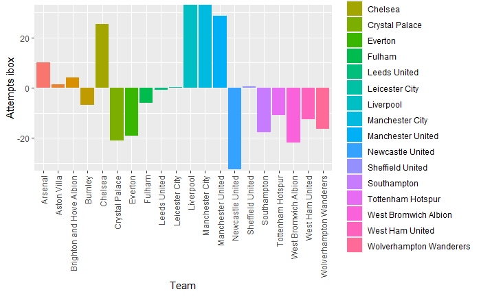

```r
ggplot(means,aes(team,attempts_ibox_av_diff,fill=team))+
  geom_bar(stat="identity")+
  labs(x= "Team", y= "Attempts ibox") +
  theme(axis.text.x = element_text(angle = 90, vjust = 0.5, hjust=1)) +
  coord_cartesian(ylim = c(-30, 30))
```

### As we suggest that all statistics are independent and have the same weight for our model, we decided to introduce such parameter as rating R. $$R = 1/4 *(\text{final_third_entries_mean+attempts_obox_mean+attempts_ibox_mean+total_offside_mean})-1/3*(\text{total_tackle_mean+blocked_pass_mean+interception_mean})$$

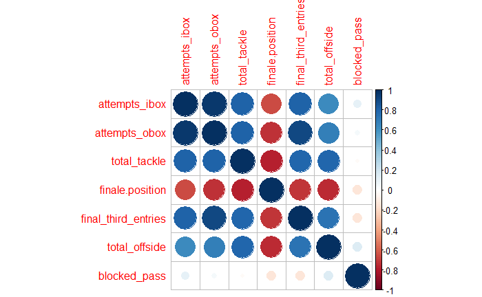

```r
cor <- cor(means[, c('attempts_ibox', 'attempts_obox', 'total_tackle', 'finale.position', 'final_third_entries', 'total_offside', 'blocked_pass')])
corrplot(cor, method = "circle")
```

### Then we calucalted the mean of these ratings and all teams with rating less than mean are defensive, bigger than mean are aggressive. After this, we filtered all the matches and splitted them into 2 categories: **matches between 2 aggressive teams and matches between 2 defensive teams.**

```r
aggressive <- read.csv(file = 'data/strategies/agressive.csv');
defensive <- read.csv(file = 'data/strategies/defensive.csv');
```

## Filtered data for matches between 2 aggressive teams and the analysis of 1 hypothese:

```r
filtered_aggressive = aggressive[aggressive$first_half_goals1 + aggressive$first_half_goals2 < 2,]
filtered_aggressive
```

|  | team1 | team2 | score1 | score2 | first_half_goals1 | first_half_goals2 | rating1 | rating2 | strategy1 | strategy2 |
| --- | --- | --- | --- | --- | --- | --- | --- | --- | --- | --- |
| 1 | Arsenal | Liverpool | 0 | 3 | 0 | 0 | 5.3903509 | 7.6557018 | 1 | 1 |
| 4 | Burnley | Liverpool | 0 | 3 | 1 | 0 | 6.6052632 | 7.6557018 | 1 | 1 |
| 5 | Chelsea | Liverpool | 0 | 2 | 0 | 0 | 3.2609649 | 7.6557018 | 1 | 1 |
| 7 | Arsenal | Manchester City | 0 | 1 | 1 | 0 | 5.3903509 | 7.9868421 | 1 | 1 |
| 9 | Liverpool | Manchester City | 1 | 4 | 0 | 0 | 7.6557018 | 7.9868421 | 1 | 1 |
| 12 | Manchester United | Manchester City | 0 | 0 | 0 | 0 | 3.6557018 | 7.9868421 | 1 | 1 |
| 13 | Arsenal | Manchester United | 0 | 0 | 0 | 0 | 5.3903509 | 3.6557018 | 1 | 1 |
| 14 | Aston Villa | Manchester United | 1 | 3 | 1 | 0 | 4.9254386 | 3.6557018 | 1 | 1 |
| 15 | Liverpool | Manchester United | 0 | 0 | 0 | 0 | 7.6557018 | 3.6557018 | 1 | 1 |
| 16 | Manchester City | Manchester United | 0 | 2 | 1 | 0 | 7.9868421 | 3.6557018 | 1 | 1 |

[output cut: 137 more lines]

```r
success = 0
diff_aggressive = c()
for (match in 1:nrow(filtered_aggressive)) {
  score1 = filtered_aggressive[match, "score1"]
  score2 = filtered_aggressive[match, "score2"]
  first_half_goals1 = filtered_aggressive[match, "first_half_goals1"]
  first_half_goals2 = filtered_aggressive[match, "first_half_goals2"]

  score = score1 + score2
  half_score = first_half_goals1 + first_half_goals2
  if(score - half_score >= 2){
    success = success + 1
  }
  diff_aggressive = c(diff_aggressive, score - half_score)
}
cat("Success of such a strategy is", success/nrow(filtered_aggressive)*100,"%")
```

```
Success of such a strategy is 55.10204 %
```

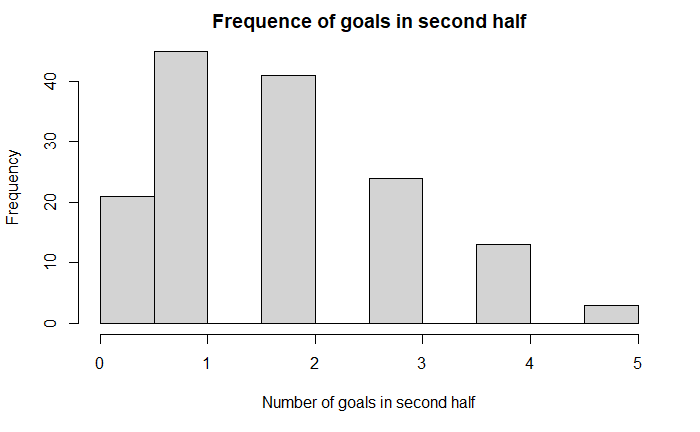

```r
hist(diff_aggressive, main = "Frequence of goals in second half", xlab = "Number of goals in second half")
```

### As we have 55.10204% as an average success of our strategy, it means that it will be profitable to use it in betting since the average coefficient for such strategy will be $$1/0.55=1.81$$ .

## Filtered data for matches between 2 defensive teams and the analysis of 2 hypothese:

```r
filtered_defensive = defensive[defensive$first_half_goals1 + defensive$first_half_goals2 > 2,]
filtered_defensive
```

|  | team1 | team2 | score1 | score2 | first_half_goals1 | first_half_goals2 | rating1 | rating2 | strategy1 | strategy2 |
| --- | --- | --- | --- | --- | --- | --- | --- | --- | --- | --- |
| 3 | Leicester City | Brighton and Hove Albion | 3 | 0 | 3 | 0 | 1.84210526 | 2.5328947 | 0 | 0 |
| 9 | Everton | Brighton and Hove Albion | 4 | 2 | 2 | 1 | 0.14473684 | 2.5328947 | 0 | 0 |
| 15 | Leicester City | West Bromwich Albion | 3 | 0 | 3 | 0 | 1.84210526 | 2.2960526 | 0 | 0 |
| 18 | Wolverhampton Wanderers | West Bromwich Albion | 2 | 3 | 2 | 1 | 0.96929825 | 2.2960526 | 0 | 0 |
| 20 | Everton | West Bromwich Albion | 5 | 2 | 2 | 1 | 0.14473684 | 2.2960526 | 0 | 0 |
| 25 | Fulham | Everton | 2 | 3 | 1 | 3 | 1.70833333 | 0.1447368 | 0 | 0 |
| 32 | Crystal Palace | Everton | 1 | 2 | 1 | 2 | -0.41447368 | 0.1447368 | 0 | 0 |
| 37 | Leeds United | Fulham | 4 | 3 | 2 | 1 | 1.50657895 | 1.7083333 | 0 | 0 |
| 50 | Leeds United | Tottenham Hotspur | 3 | 1 | 2 | 1 | 1.50657895 | 1.2236842 | 0 | 0 |
| 58 | Newcastle United | Tottenham Hotspur | 2 | 2 | 1 | 2 | 1.40131579 | 1.2236842 | 0 | 0 |

[output cut: 55 more lines]

```r
success = 0
diff_defensive = c()
for (match in 1:nrow(filtered_defensive)) {
  score1 = filtered_defensive[match, "score1"]
  score2 = filtered_defensive[match, "score2"]
  first_half_goals1 = filtered_defensive[match, "first_half_goals1"]
  first_half_goals2 = filtered_defensive[match, "first_half_goals2"]

  score = score1 + score2
  half_score = first_half_goals1 + first_half_goals2
  if(score - half_score < 2){
    success = success + 1
  }
  diff_defensive = c(diff_defensive, score - half_score)
}
cat("Success of such a strategy is", success/nrow(filtered_defensive)*100,"%")
```

```
Success of such a strategy is 63.07692 %
```

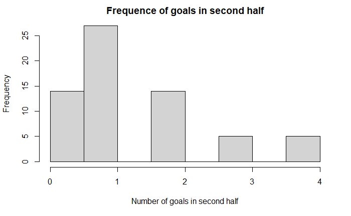

```r
hist(diff_defensive, main = "Frequence of goals in second half", xlab = "Number of goals in second half")
```

### As we have 63.07692% as an average success of our strategy, it means that it will be profitable to use it in betting since the average coefficient for such strategy will be $$1/0.63=1.59$$ .

## Conclusions: to continue testing these hypotheses, we have to analyze betting market and find the average coefficient for each strategy for a long distance. If these coefficients will be equall or higher than $1.81$ and $1.59$ for 1 and 2 hypothese respectively, we have to accept them and use them in betting, receiving income!